# Market Area Analysis - Detroit

We are going to explore price changes in the property and analyze how the price has changed with respect to the property tax, income by location, housing size and also considering other contributing factors like commute time, local business. Later on, we will correlate the prices with major cities and smaller cities in the US.

There are 14 columns in first dataset (1999-03-01 to 2017-06-01) - 'All Homes', 'Single Family Residance', 'Middle Tier', 'Bottom Tier', 'Condominium', '5 bedroom_more', '4 bedroom', '3 bedroom', '2 bedroom', '1 bedroom', 'Turnover All Homes', 'Pct Of Home increasing Values All Homes', 'Pct Of Home Decreasing Values All Homes','Median Value Per SqrFt All Homes'

AND 9 columns in Second DataFrame (2010-11-01 to 2017-06-01) - 'Price to rent ratio all Homes', 'Pct of Listing Price Reduction single Family Residance', 'Pct of Listing Price Reduction Condominum', 'Pct of Listing Price Reduction All Homes', 'Per sqr fit All Homes', 'Median Sold Price All Homes', 'Median Pct Of Price Reduction Single Family Residance', 'Median Price Cut Dollar All Homes', 'Price Cut Seas Adj All Homes'

Further I will be exploring with respect to other cities, stock market, government policies, and modeling for home pricing.

#### First of all import all required lIbaries

```python
# import
import pandas as pd
import numpy as np
import requests
import matplotlib.pyplot as plt
import seaborn as sns
from scipy import stats
from scipy.stats import norm
from bokeh.plotting import figure
from bokeh.charts import Bar
from bokeh.io import output_file, show
from sklearn.preprocessing import StandardScaler
import warnings
warnings.filterwarnings('ignore')
%matplotlib inline
```

```python
Mortage_Data = pd.read_excel('Detroit//Detrooit_Mortage_Data.xlsx', sheetname = 'Sheet1')
```

##### Let's look at datatypes and if year is in object then we will change into DateTime and set as Index and repeat same for other DataFrame

```python
Mortage_Data.dtypes
```

```
Year                                   object
All_homes                               int64
Single_Family_Residance                 int64
Middle_Tier                             int64
Bottom_tier                             int64
Condominium                             int64
5_bedroom_more                          int64
4_bedroom                               int64
3_bedroom                               int64
2_bedroom                               int64
1_bedroom                               int64
Turnover_AllHomes                     float64
PctOfHomeincreasingValues_AllHomes    float64
PctOfHomeDecreasingValues_AllHomes    float64
MedianValuePerSqrFt_AllHomes            int64
dtype: object
```

```python
Mortage_Data['Year'] = pd.to_datetime(Mortage_Data['Year'])
```

```python
Mortage_Data.set_index('Year',inplace=True)
```

```python
Mortage_Data.head()
```

| Year | All_homes | Single_Family_Residance | Middle_Tier | Bottom_tier | Condominium | 5_bedroom_more | 4_bedroom | 3_bedroom | 2_bedroom | 1_bedroom | Turnover_AllHomes | PctOfHomeincreasingValues_AllHomes | PctOfHomeDecreasingValues_AllHomes | MedianValuePerSqrFt_AllHomes |
| --- | --- | --- | --- | --- | --- | --- | --- | --- | --- | --- | --- | --- | --- | --- |
| 1999-03-01 | 59400 | 136200 | 59400 | 46300 | 69700 | 109400 | 72100 | 62600 | 50500 | 51300 | 0.4805 | 63.90 | 32.69 | 54 |
| 1999-04-01 | 59300 | 137300 | 59300 | 46700 | 70400 | 109700 | 72900 | 63200 | 50700 | 51400 | 0.4833 | 64.71 | 32.94 | 55 |
| 1999-05-01 | 59400 | 138200 | 59400 | 47000 | 70400 | 109600 | 74200 | 64200 | 51700 | 51800 | 0.4926 | 65.76 | 31.27 | 55 |
| 1999-06-01 | 60000 | 138900 | 60000 | 47300 | 70600 | 111300 | 75300 | 64800 | 52300 | 52100 | 0.4722 | 78.61 | 18.93 | 56 |
| 1999-07-01 | 60300 | 140000 | 60300 | 47600 | 70100 | 113100 | 76600 | 65500 | 52900 | 52400 | 0.4389 | 86.33 | 11.82 | 57 |

```python
Mortage_Data.tail()
```

| Year | All_homes | Single_Family_Residance | Middle_Tier | Bottom_tier | Condominium | 5_bedroom_more | 4_bedroom | 3_bedroom | 2_bedroom | 1_bedroom | Turnover_AllHomes | PctOfHomeincreasingValues_AllHomes | PctOfHomeDecreasingValues_AllHomes | MedianValuePerSqrFt_AllHomes |
| --- | --- | --- | --- | --- | --- | --- | --- | --- | --- | --- | --- | --- | --- | --- |
| 2017-02-01 | 38700 | 325900 | 38700 | 32600 | 69300 | 76500 | 45300 | 37100 | 34300 | 50200 | 0.5596 | 92.26 | 6.25 | 38 |
| 2017-03-01 | 39600 | 330900 | 39600 | 33100 | 69600 | 76900 | 45900 | 37700 | 34700 | 50800 | 0.3775 | 93.75 | 5.03 | 39 |
| 2017-04-01 | 40700 | 334400 | 40700 | 33800 | 70600 | 78000 | 46400 | 38200 | 35200 | 51200 | 0.1802 | 95.49 | 3.54 | 39 |
| 2017-05-01 | 41800 | 334500 | 41800 | 34500 | 71900 | 79600 | 47300 | 38700 | 35700 | 51100 | 0.1149 | 95.97 | 3.15 | 40 |
| 2017-06-01 | 42600 | 334100 | 42600 | 35100 | 72900 | 81000 | 48700 | 39400 | 36300 | 50800 | 0.1045 | 96.13 | 2.94 | 41 |

```python
Mortage_Data.columns.tolist()
```

```
['All_homes',
 'Single_Family_Residance',
 'Middle_Tier',
 'Bottom_tier',
 'Condominium',
 '5_bedroom_more',
 '4_bedroom',
 '3_bedroom',
 '2_bedroom',
 '1_bedroom',
 'Turnover_AllHomes',
 'PctOfHomeincreasingValues_AllHomes',
 'PctOfHomeDecreasingValues_AllHomes',
 'MedianValuePerSqrFt_AllHomes']
```

```python
Mortage_Per_Data = pd.read_excel('Detroit//Detrooit_Mortage_Data.xlsx', sheetname = 'price_to_rent_ratio')
```

```python
Mortage_Per_Data.dtypes
```

```
Year                                                  object
Price_to_rent_ratio_all_Homes                        float64
PctofListing_PriceReduction_singleFamilyResidance    float64
PctofListing_PriceReduction_Condominum               float64
PctofListing_PriceReduction_AllHomes                 float64
Per_sqr_fit_AllHomes                                 float64
MedianSoldPrice_AllHomes                             float64
MedianPctOfPriceReduction_SingleFamilyResidance      float64
Median_Price_Cut_Dollar_AllHomes                     float64
PriceCut_SeasAdj_AllHomes                            float64
dtype: object
```

```python
Mortage_Per_Data['Year'] = pd.to_datetime(Mortage_Per_Data['Year'])
```

```python
Mortage_Per_Data.set_index('Year',inplace=True)
```

```python
Mortage_Per_Data.head()
```

| Year | Price_to_rent_ratio_all_Homes | PctofListing_PriceReduction_singleFamilyResidance | PctofListing_PriceReduction_Condominum | PctofListing_PriceReduction_AllHomes | Per_sqr_fit_AllHomes | MedianSoldPrice_AllHomes | MedianPctOfPriceReduction_SingleFamilyResidance | Median_Price_Cut_Dollar_AllHomes | PriceCut_SeasAdj_AllHomes |
| --- | --- | --- | --- | --- | --- | --- | --- | --- | --- |
| 2010-11-01 | 4.17 | 7.666667 | 5.202312 | 7.585815 | 0.816 | 19300.0 | 16.877938 | 4000.0 | 8.228547 |
| 2010-12-01 | 4.23 | 9.973333 | 6.896552 | 9.881014 | 0.816 | 16960.0 | 12.500000 | 1860.0 | 10.529425 |
| 2011-01-01 | 4.37 | 10.046148 | 4.419890 | 9.871023 | 0.808 | 18290.0 | 14.326648 | 2000.0 | 9.218498 |
| 2011-02-01 | 4.32 | 10.535943 | 7.909605 | 10.453579 | 0.800 | 19550.0 | 13.636364 | 1440.0 | 11.036967 |
| 2011-03-01 | 4.32 | 9.838370 | 7.428571 | 9.766491 | 0.792 | 18000.0 | 15.789474 | 1910.0 | 8.943306 |

```python
Mortage_Per_Data.count()
```

```
Price_to_rent_ratio_all_Homes                        80
PctofListing_PriceReduction_singleFamilyResidance    80
PctofListing_PriceReduction_Condominum               80
PctofListing_PriceReduction_AllHomes                 80
Per_sqr_fit_AllHomes                                 80
MedianSoldPrice_AllHomes                             67
MedianPctOfPriceReduction_SingleFamilyResidance      80
Median_Price_Cut_Dollar_AllHomes                     80
PriceCut_SeasAdj_AllHomes                            80
dtype: int64
```

```python
Mortage_Per_Data.columns.tolist()
```

```
['Price_to_rent_ratio_all_Homes',
 'PctofListing_PriceReduction_singleFamilyResidance',
 'PctofListing_PriceReduction_Condominum',
 'PctofListing_PriceReduction_AllHomes',
 'Per_sqr_fit_AllHomes',
 'MedianSoldPrice_AllHomes',
 'MedianPctOfPriceReduction_SingleFamilyResidance',
 'Median_Price_Cut_Dollar_AllHomes',
 'PriceCut_SeasAdj_AllHomes']
```

```python
Home_price_index_year = pd.read_excel('Detroit//Home_price_index_yearwise.xlsx')
```

```python
Home_price_index_year.head()
```

|  | Year | DetroitHomePriceIndex_PctChangefromPrevious Year | USHomePriceIndex_PctChangefromPrevious Year |
| --- | --- | --- | --- |
| 0 | 1992 | 0.032 | -0.007 |
| 1 | 1993 | 0.034 | -0.017 |
| 2 | 1994 | 0.053 | 0.007 |
| 3 | 1995 | 0.076 | 0.002 |
| 4 | 1996 | 0.076 | 0.009 |

```python
Home_price_index_year.set_index('Year', inplace=True)
```

###### Lets visualize the home price index Detroit VS USA and observe the change

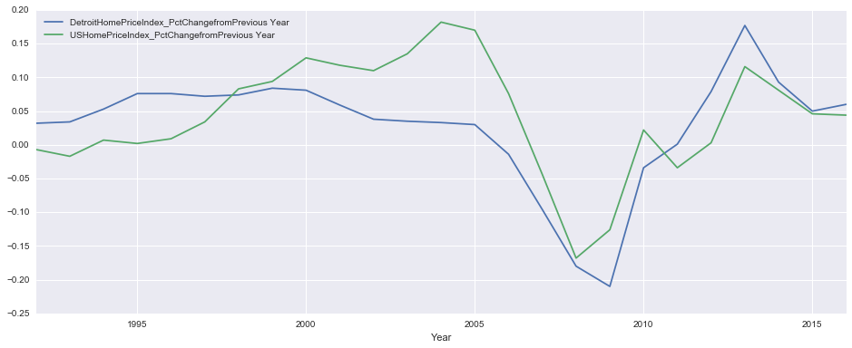

```python
Home_price_index_year.plot(figsize=(16,6))
```

Detroit Home Index Price is recently increased after year 2015 This **[article](http://www.crainsdetroit.com/article/20160114/NEWS/160119881/metro-detroit-home-sales-prices-rise-in-2015)** is proof for that.

Lets Explore more about price changes with resepect time in All Home, Single Family Residance and all other remaining categories.

```python
Mortage_Per_Data.head()
```

| Year | Price_to_rent_ratio_all_Homes | PctofListing_PriceReduction_singleFamilyResidance | PctofListing_PriceReduction_Condominum | PctofListing_PriceReduction_AllHomes | Per_sqr_fit_AllHomes | MedianSoldPrice_AllHomes | MedianPctOfPriceReduction_SingleFamilyResidance | Median_Price_Cut_Dollar_AllHomes | PriceCut_SeasAdj_AllHomes |
| --- | --- | --- | --- | --- | --- | --- | --- | --- | --- |
| 2010-11-01 | 4.17 | 7.666667 | 5.202312 | 7.585815 | 0.816 | 19300.0 | 16.877938 | 4000.0 | 8.228547 |
| 2010-12-01 | 4.23 | 9.973333 | 6.896552 | 9.881014 | 0.816 | 16960.0 | 12.500000 | 1860.0 | 10.529425 |
| 2011-01-01 | 4.37 | 10.046148 | 4.419890 | 9.871023 | 0.808 | 18290.0 | 14.326648 | 2000.0 | 9.218498 |
| 2011-02-01 | 4.32 | 10.535943 | 7.909605 | 10.453579 | 0.800 | 19550.0 | 13.636364 | 1440.0 | 11.036967 |
| 2011-03-01 | 4.32 | 9.838370 | 7.428571 | 9.766491 | 0.792 | 18000.0 | 15.789474 | 1910.0 | 8.943306 |

```python
All_homes =  Mortage_Data['All_homes']
Single_Family_Residance = Mortage_Data['Single_Family_Residance']
```

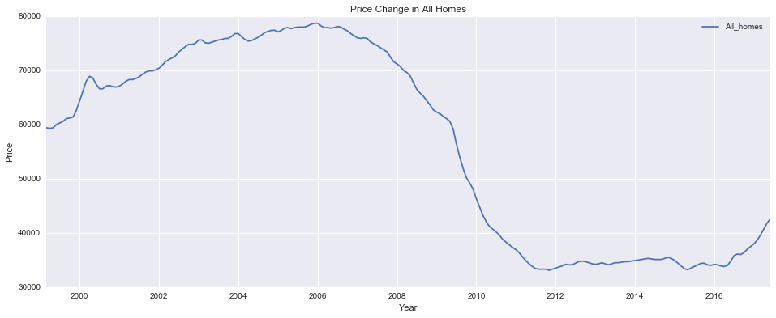

```python
plt.figure(figsize=(16,6))
plt.plot(All_homes)
plt.ylabel('Price')
plt.xlabel('Year')
plt.title('Price Change in All Homes')
plt.legend()
plt.show()
```

#### This clearly shows that the all home prices were reduced after economic clash 2007-2008. Now, it is started increasing and lets zoom from after 2016

```python
homes_df =  Mortage_Data.All_homes.ix['2016-01-01':'2017-06-01']
```

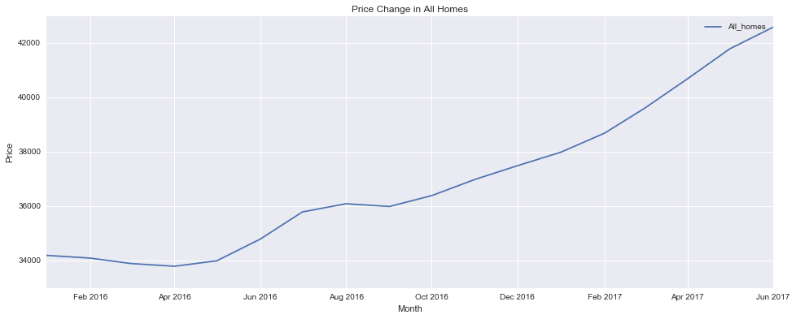

```python
plt.figure(figsize=(16,6))
plt.plot(homes_df)
plt.ylabel('Price')
plt.xlabel('Month')
plt.title('Price Change in All Homes')
plt.legend()
plt.show()
```

#### Lets check for Single Family Residence pricing

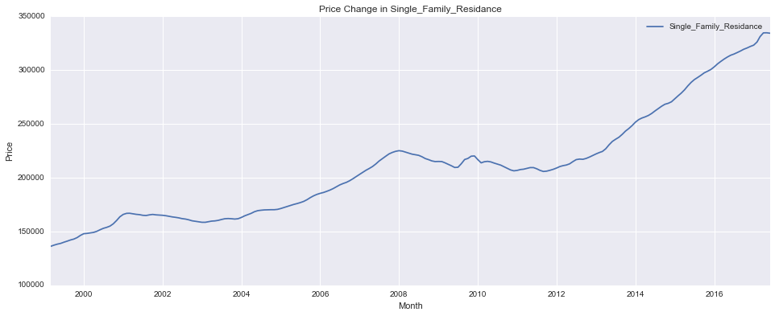

```python
plt.figure(figsize=(16,6))
plt.plot(Single_Family_Residance)
plt.ylabel('Price')
plt.xlabel('Month')
plt.title('Price Change in Single_Family_Residance')
plt.legend()
plt.show()
```

After Aug 2016 price started to increase steadily from 36000 to 42600. According to **[post](https://www.usatoday.com/story/money/2016/12/08/mortgages-interest-rates/95138730/)**, anticipation new govermental change, the average interest change in 30-year, 15-year mortgage and refinancing.

Lets combine, All Homes VS Single Family Residance

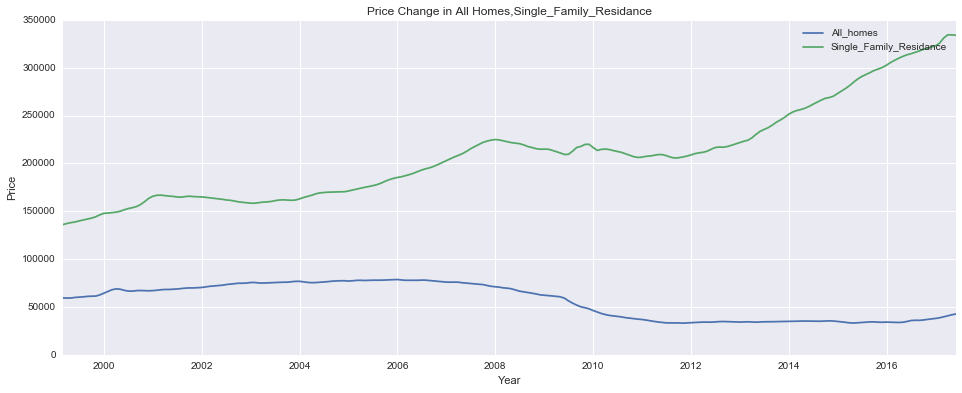

```python
#plot
plt.figure(figsize=(16,6))
plt.plot(All_homes)
plt.plot(Single_Family_Residance)
plt.ylabel('Price')
plt.xlabel('Year')
plt.title('Price Change in All Homes,Single_Family_Residance')
plt.legend()
plt.show()
```

##### Lets explore about Tiers and Condominium

```python
Middle_Tier = Mortage_Data['Middle_Tier']
Bottom_tier = Mortage_Data['Bottom_tier']
Condominium = Mortage_Data['Condominium']
```

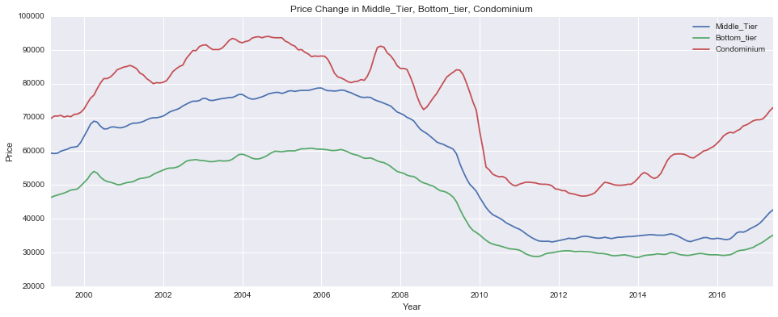

```python
plt.figure(figsize=(16,6))
plt.plot(Middle_Tier)
plt.plot(Bottom_tier)
plt.plot(Condominium)
plt.ylabel('Price')
plt.xlabel('Year')
plt.title('Price Change in Middle_Tier, Bottom_tier, Condominium')
plt.legend()
plt.show()
```

###### Lets check about price changes with respect to bedrooom size

```python
Mortage_Data.head()
```

| Year | All_homes | Single_Family_Residance | Middle_Tier | Bottom_tier | Condominium | 5_bedroom_more | 4_bedroom | 3_bedroom | 2_bedroom | 1_bedroom | Turnover_AllHomes | PctOfHomeincreasingValues_AllHomes | PctOfHomeDecreasingValues_AllHomes | MedianValuePerSqrFt_AllHomes |
| --- | --- | --- | --- | --- | --- | --- | --- | --- | --- | --- | --- | --- | --- | --- |
| 1999-03-01 | 59400 | 136200 | 59400 | 46300 | 69700 | 109400 | 72100 | 62600 | 50500 | 51300 | 0.4805 | 63.90 | 32.69 | 54 |
| 1999-04-01 | 59300 | 137300 | 59300 | 46700 | 70400 | 109700 | 72900 | 63200 | 50700 | 51400 | 0.4833 | 64.71 | 32.94 | 55 |
| 1999-05-01 | 59400 | 138200 | 59400 | 47000 | 70400 | 109600 | 74200 | 64200 | 51700 | 51800 | 0.4926 | 65.76 | 31.27 | 55 |
| 1999-06-01 | 60000 | 138900 | 60000 | 47300 | 70600 | 111300 | 75300 | 64800 | 52300 | 52100 | 0.4722 | 78.61 | 18.93 | 56 |
| 1999-07-01 | 60300 | 140000 | 60300 | 47600 | 70100 | 113100 | 76600 | 65500 | 52900 | 52400 | 0.4389 | 86.33 | 11.82 | 57 |

```python
bedroom_five = Mortage_Data['5_bedroom_more']
bedroom_four = Mortage_Data['4_bedroom']
bedroom_three = Mortage_Data['3_bedroom']
bedroom_two = Mortage_Data['2_bedroom']
bedroom_one = Mortage_Data['1_bedroom']
```

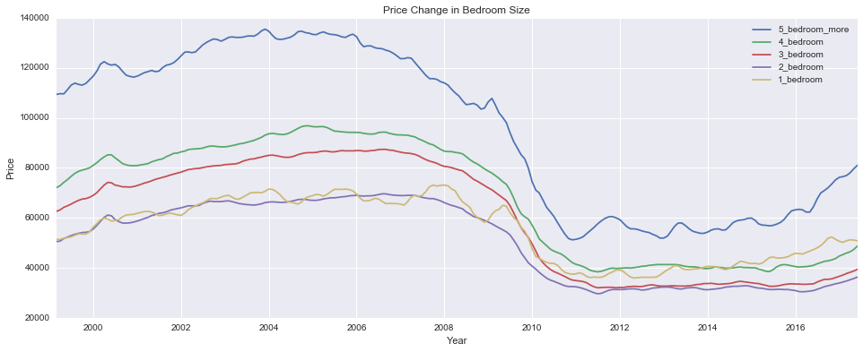

```python
plt.figure(figsize=(16,6))
plt.plot(bedroom_five)
plt.plot(bedroom_four)
plt.plot(bedroom_three)
plt.plot(bedroom_two)
plt.plot(bedroom_one)
plt.ylabel('Price')
plt.xlabel('Year')
plt.title('Price Change in Bedroom Size')
plt.legend()
plt.show()
```

#### Interesting! All graphs shows same pattern of in pricing. Further, I will be analyzing relation in PriceReduction